# AnneArundel

Nicole Williamson

Last updated: 2023-02-10

# **All Permits, 2000-2022**

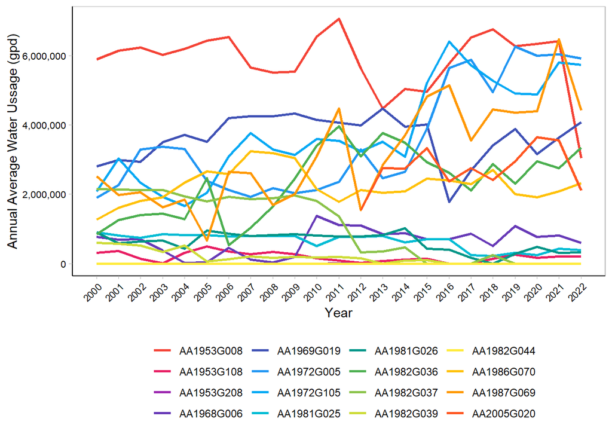

# **Model 1**

## 1979-2022 - All available data

Total water usage (solid black line) compared to system cap (dotted black line). The gray line is the linear projection of water use growth over time, based on **all previous years data.**

- Water use would exceed cap on Friday August 6, 2032
- Projected water use in 2035 is 42,309,005 GPD

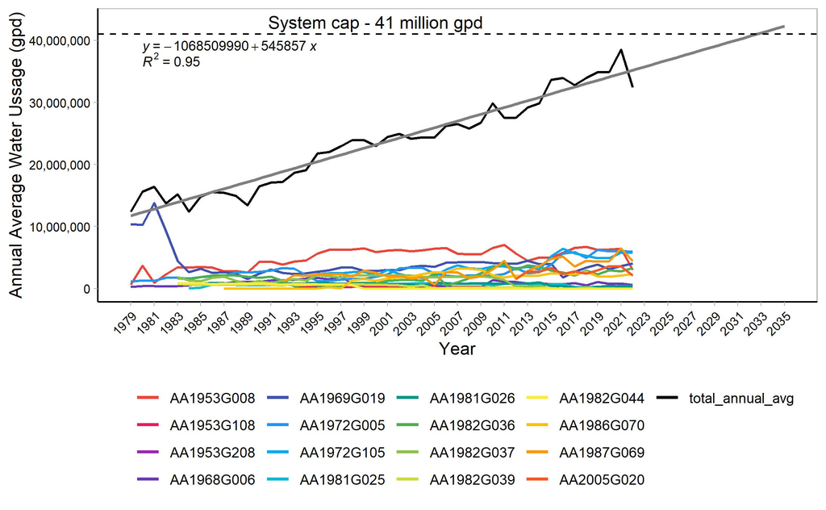

# **Model 2**

## 1998-2022 - Previous two permit periods

Total water usage (solid black line) compared to system cap (dotted black line). The gray line is the linear projection of water use growth over time, based on data from the last two permit periods **from 1998 - 2022.**

- Water use would exceed cap on Tuesday August 12, 2031
- Projected water use in 2035 is 42,925,001 GPD

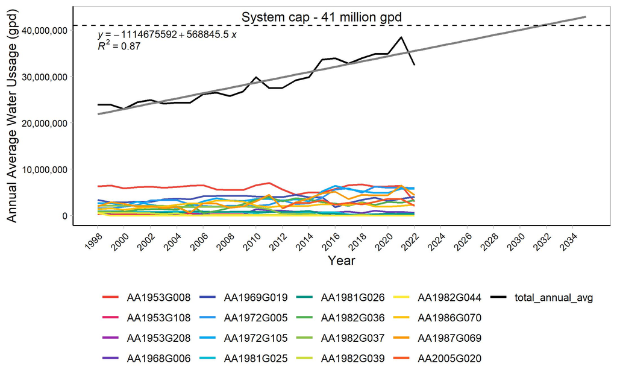

# **Model 3**

## 2010-2022 - Previous permit period

Total water usage (solid black line) compared to system cap (dotted black line). The gray line is the linear projection of water use growth over time, based on data from the last permit periods **from 2010 - 2022.**

- Water use would exceed system cap on Wednesday October 25, 2028
- Projected water use in 2035 is 45,221,247 GPD

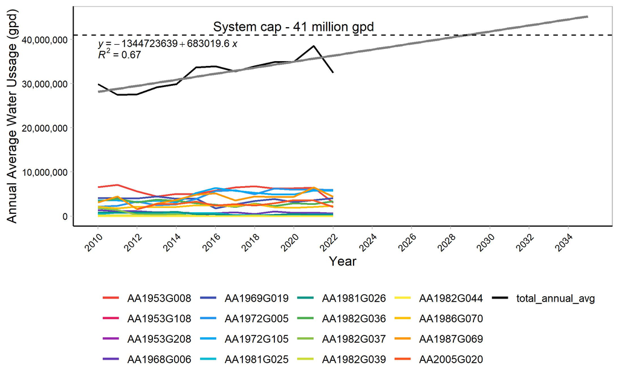

# **Individual Permit Water Usage**

## AA1953G008

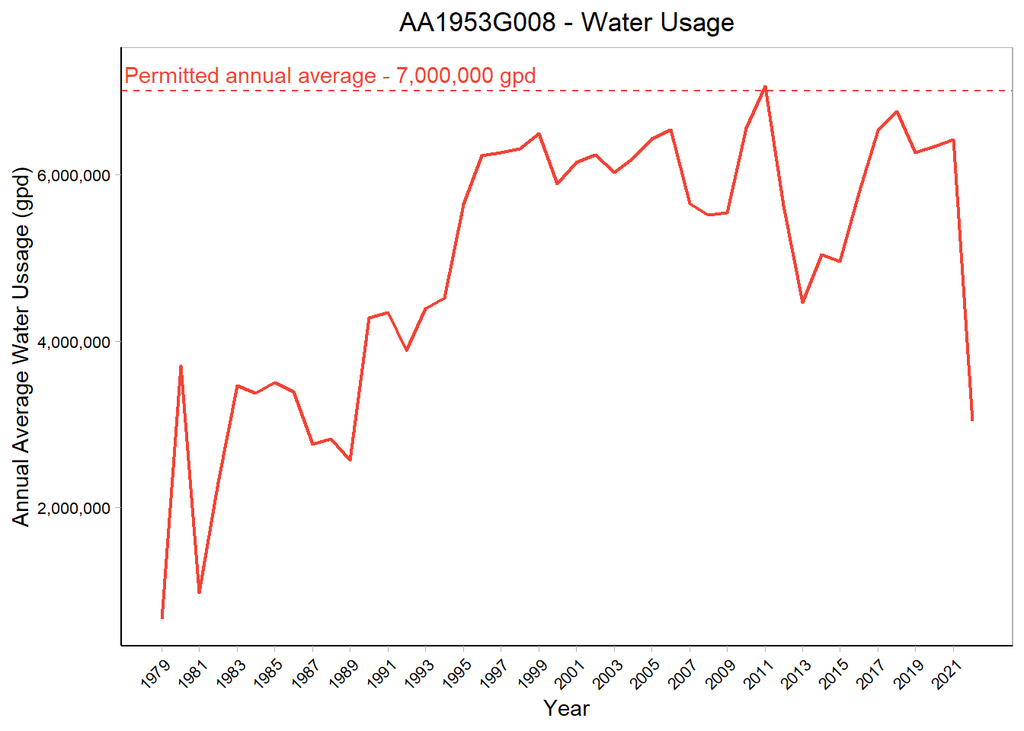

## AA1953G108

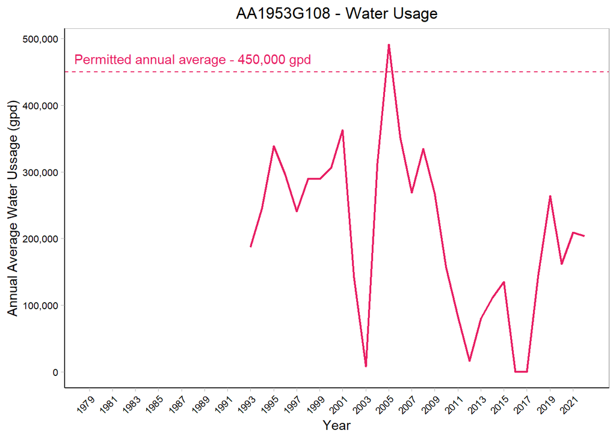

## AA1953G208

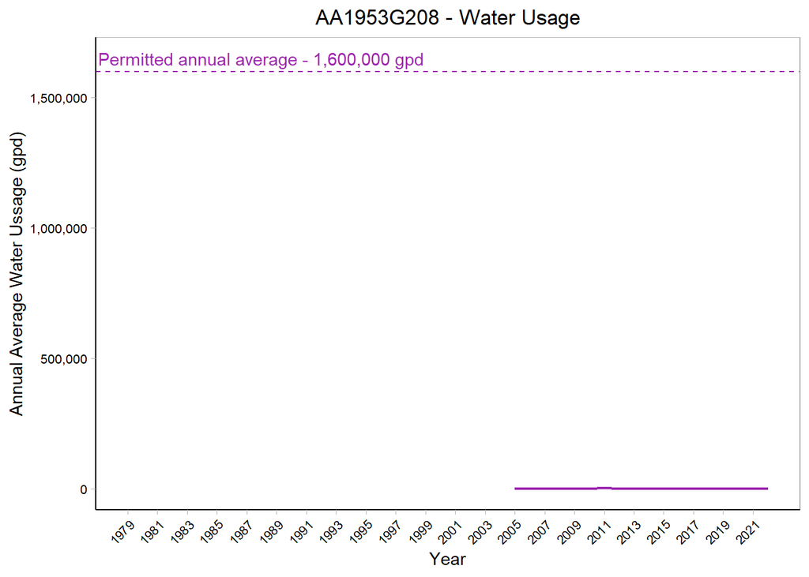

## AA1968G006

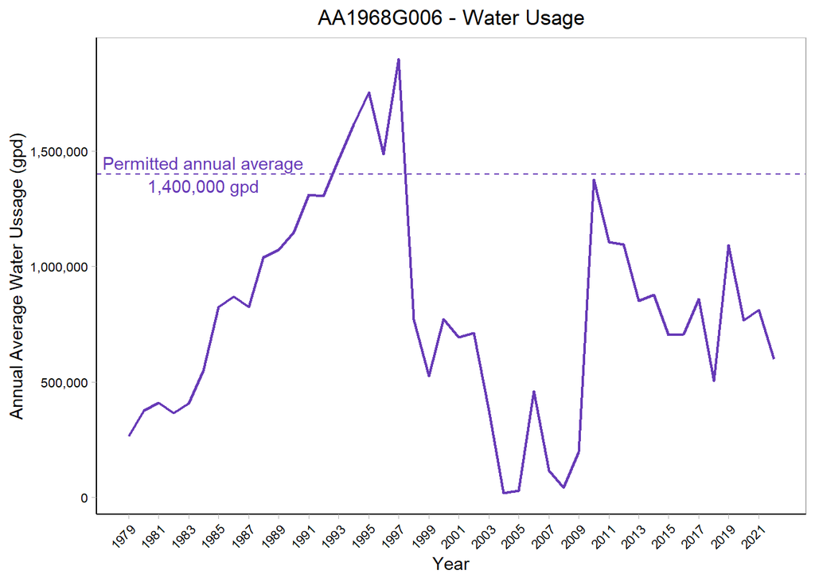

## AA1969G019

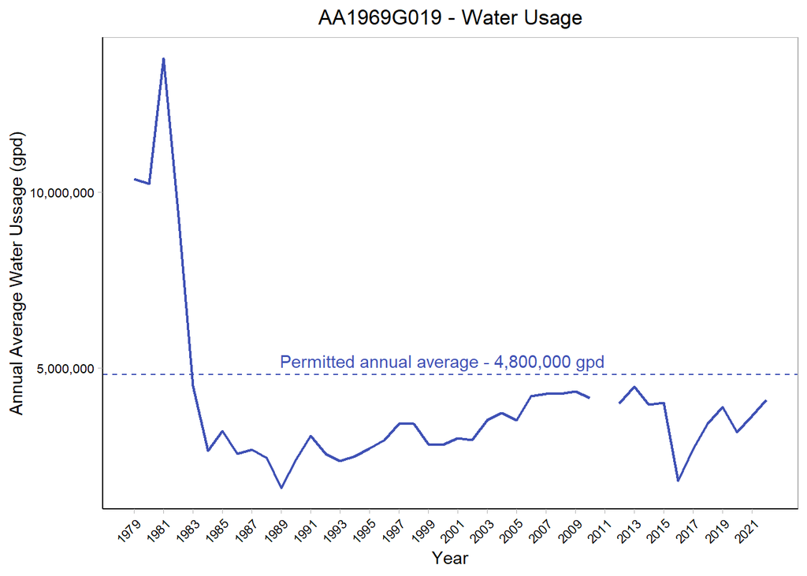

## AA1972G005

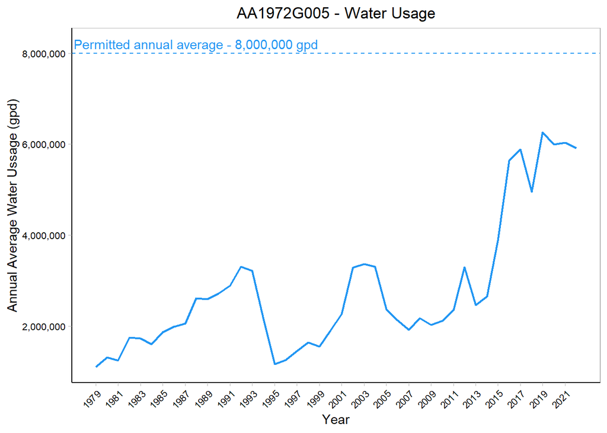

## AA1972G105

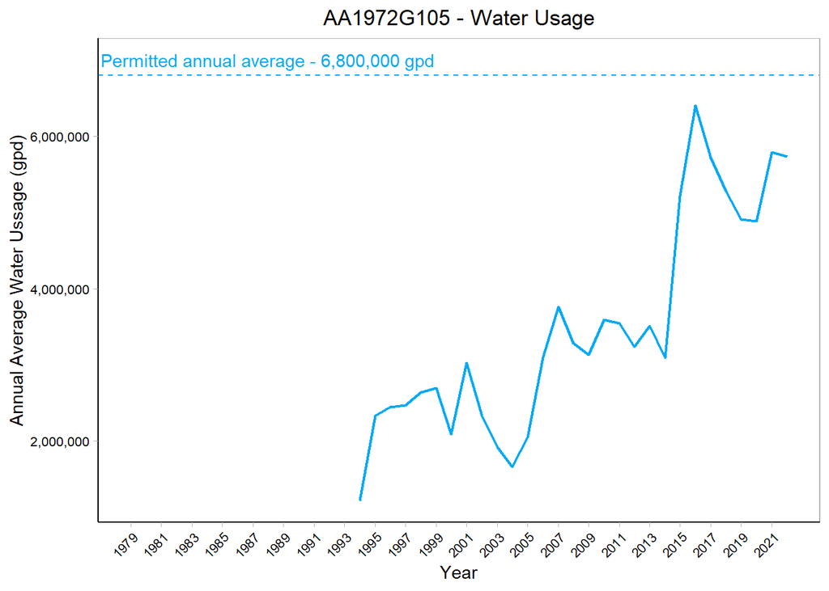

## AA1981G025

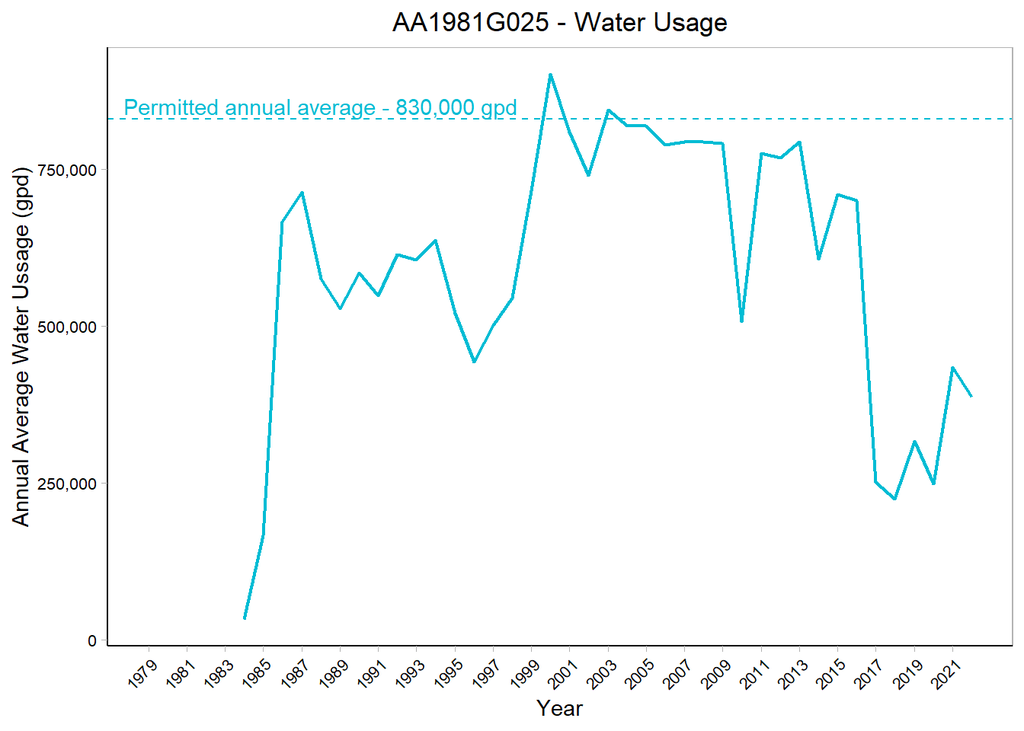

## AA1981G026

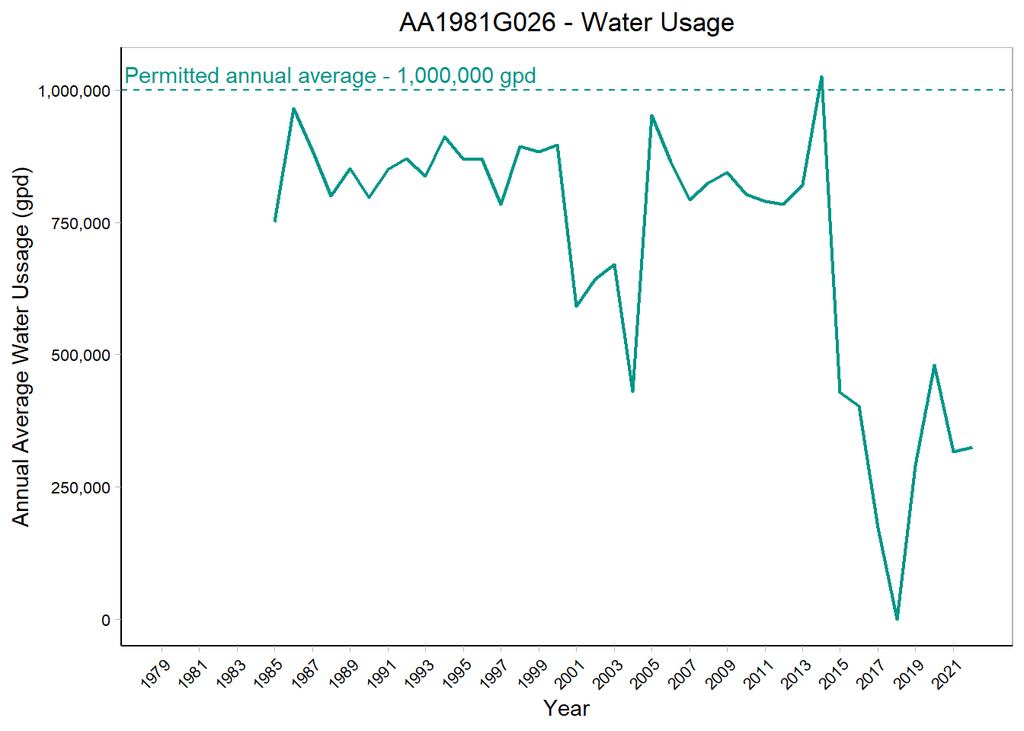

## AA1982G036

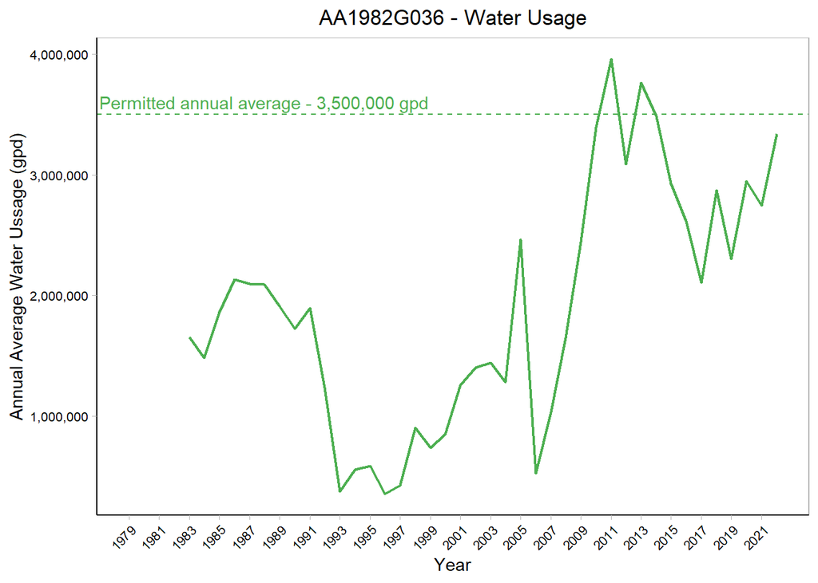

## AA1982G037

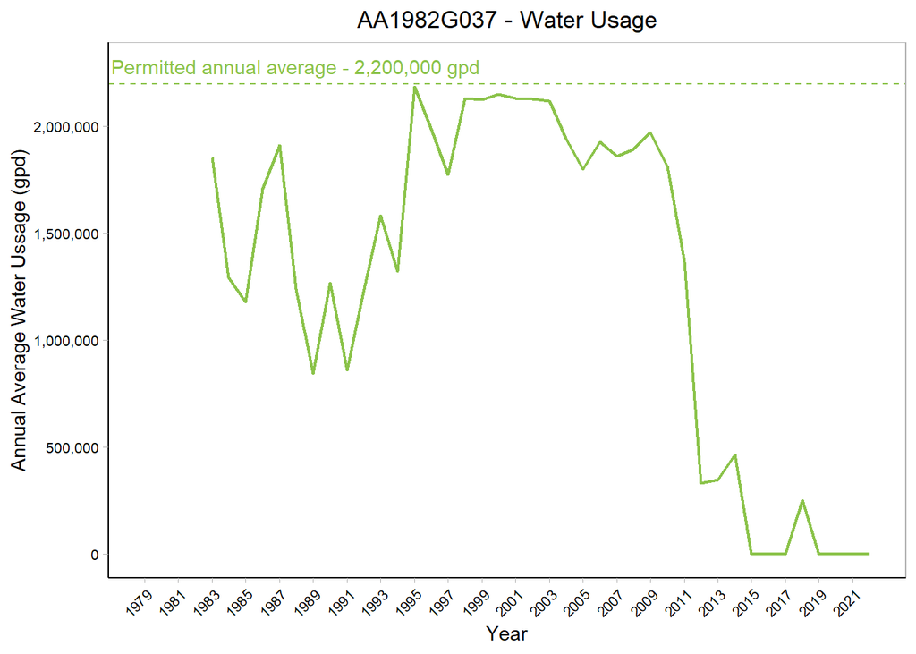

## AA1982G039

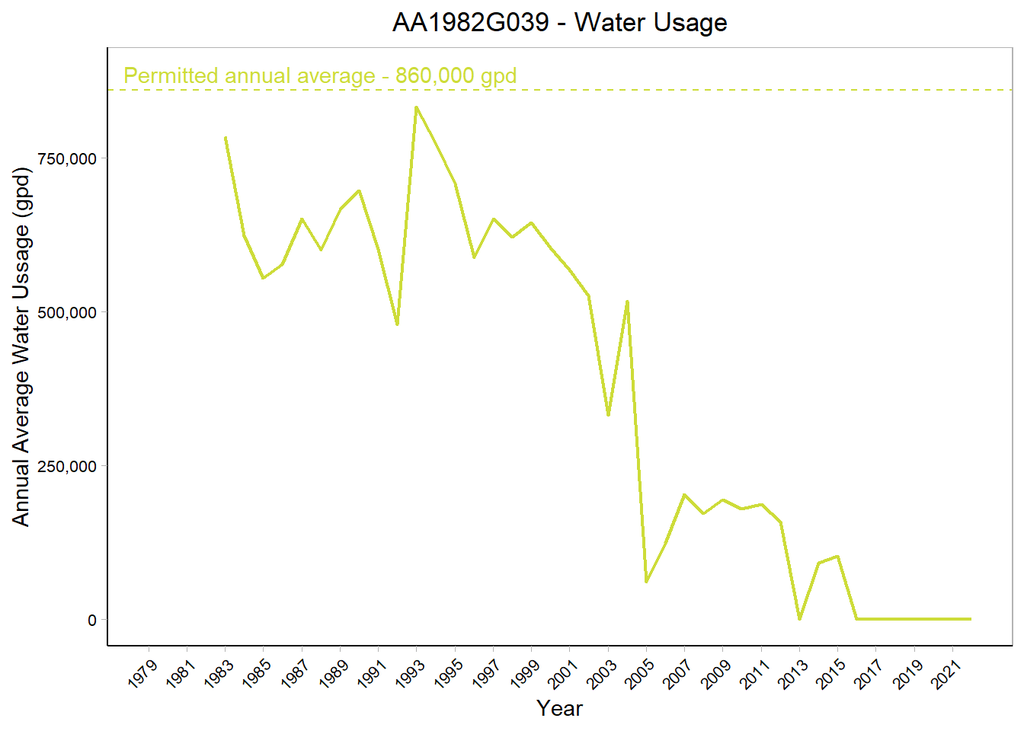

## AA1982G044

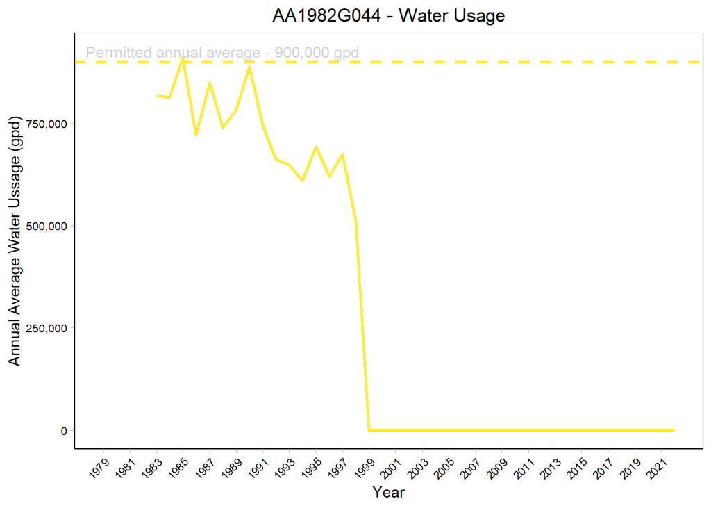

## AA1986G070

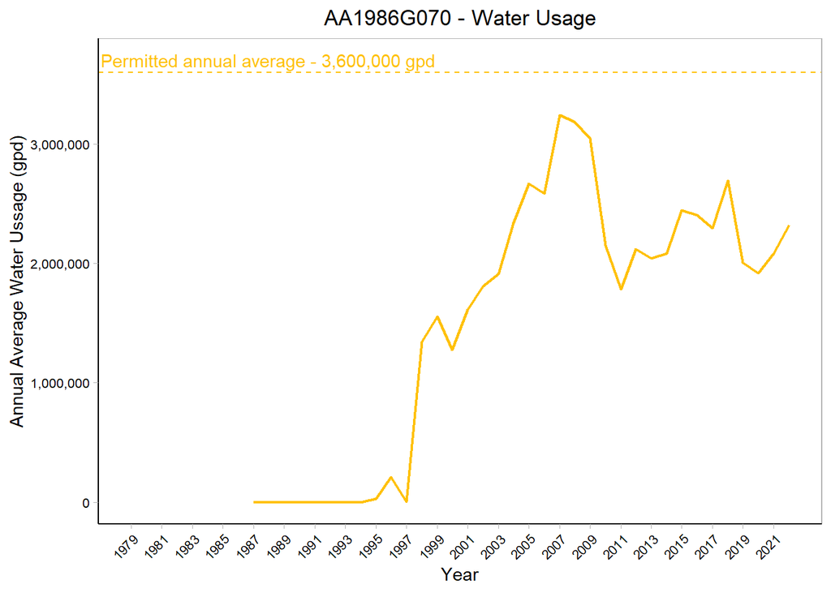

## AA1987G069

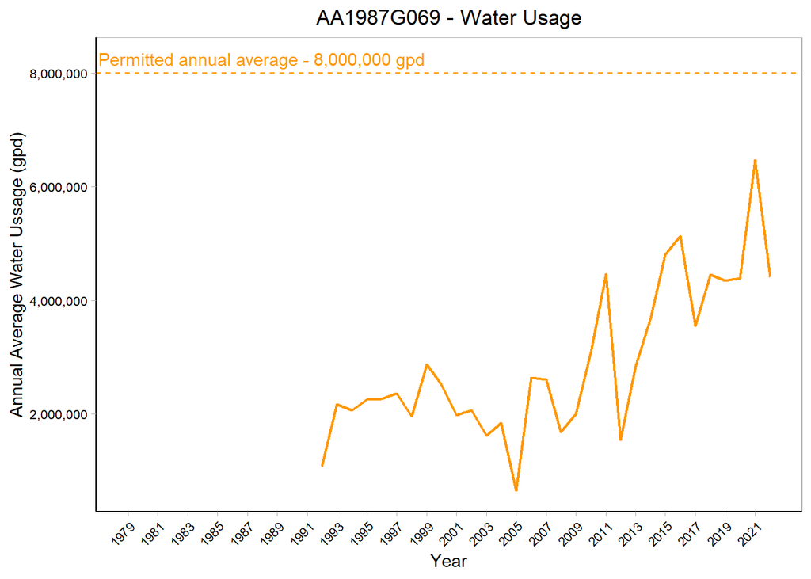

## AA2005G020

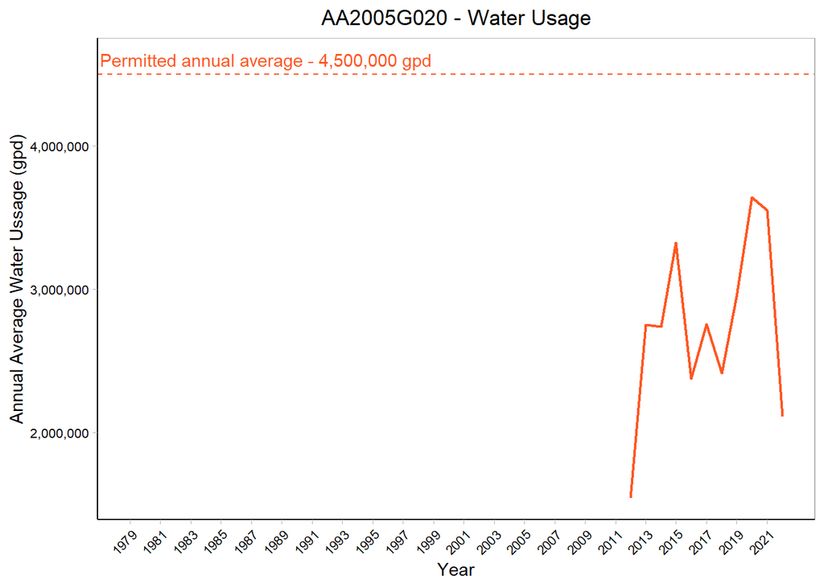

# Supplemental permit conditions

## AA1953G008 + AA1953G108 + AA1953G208

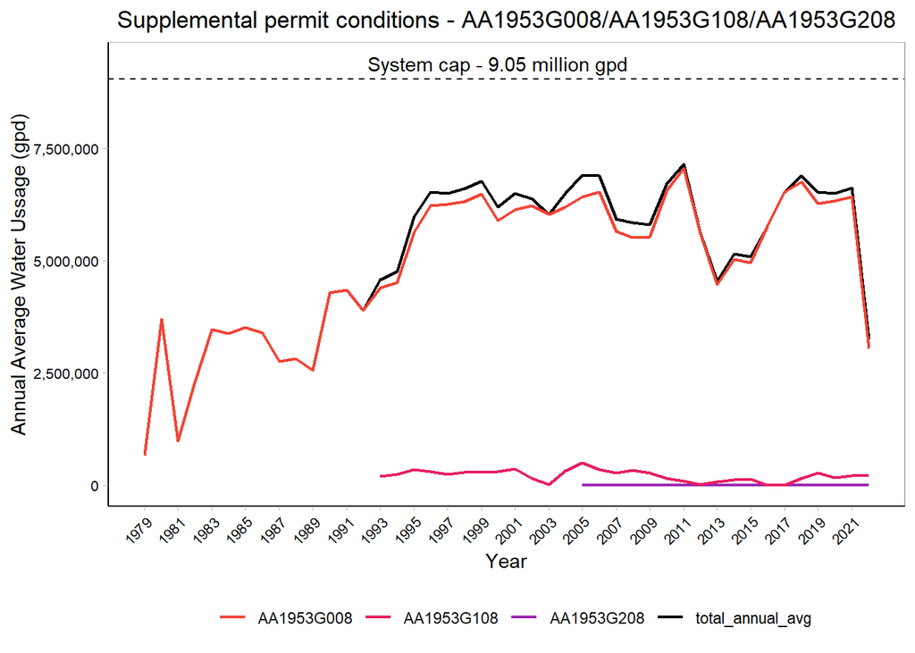